# Investigating TMDB Movie Titles

- Introduction
- Data Wrangling
- Exploratory Data Analysis
- Conclusions

## Introduction

### Dataset Description

> For this report, I will be analyzing a single-table dataset containing 10,000 titles from The Movie Database. The dataset contains many useful metrics for the titles, such as their popularity, average review, budget and revenue, keywords, genre, etc.

> The columns in the dataset are:
> - **id:** primary key, unique identifier
> - **imdb_id:** the id for each title on IMDb.
> - **popularity:** A complex metric that is built from various factors, such as number of votes, number of views, release date, and number of users adding the title to their "watchlist." More information can be found on: https://developers.themoviedb.org/3/getting-started/popularity
> - **budget:** the recorded budget of the film at time of release
> - **revenue:** the cumulative revenue made by the film by the dataset's release in 2015
> - **original_title:** the title of the film at release
> - **cast:** a list of prominent cast-members in the film
> - **homepage:** contains a link to the homepage of the movie's website
> - **director:** contains either the lead director, or a list of directors associated with the film.
> - **tagline:** the one or two sentence tagline accompanying the film's title for promotion
> - **keywords:** a list of SEO keywords for searching and indexing
> - **overview:** a brief description of the movie's plot
> - **runtime:** the length of the movie in minutes
> - **genres:** a list of genres that the film falls under
> - **production_companies:** a list of companies involved in the production of the film
> - **release_date:** the day the film was released
> - **vote_count:** the number of unique votes that have been submitted for the movie on TMDB
> - **vote_average:** the mean score calculated from all votes
> - **release_year:** the year the title was released
> - **budget_adj:** the film's budget, adjusted for inflation to 2015 dollars.
> - **revenue_adj:** the film's revenue, adjusted for inflation to 2015 dollars.

### Questions for Analysis

> There are two primary question I would like to explore in my analysis.
> 1. How have audience tastes in different genres changed over time?
> 2. What factors are associated with high-revenue films?

> *Please note that this report has been made without the use of inferential statistics or machine learning, so all findings presented are tentative.

```python
# importing packages and setting matplotlib to draw inline
import pandas as pd
import matplotlib.pyplot as plt
import numpy as np
import seaborn as sns


%matplotlib inline
```

## Data Wrangling

> Before we can do anything useful with our data, we will have to load it into a dataframe, inspect it, and clean it.

### General Properties

```python
df = pd.read_csv('tmdb-movies.csv', index_col = 'id')
df.head()
```

| id | imdb_id | popularity | budget | revenue | original_title | cast | homepage | director | tagline | keywords | overview | runtime | genres | production_companies | release_date | vote_count | vote_average | release_year | budget_adj | revenue_adj |
| --- | --- | --- | --- | --- | --- | --- | --- | --- | --- | --- | --- | --- | --- | --- | --- | --- | --- | --- | --- | --- |
| 135397 | tt0369610 | 32.985763 | 150000000 | 1513528810 | Jurassic World | Chris Pratt\|Bryce Dallas Howard\|Irrfan Khan\|Vi... | http://www.jurassicworld.com/ | Colin Trevorrow | The park is open. | monster\|dna\|tyrannosaurus rex\|velociraptor\|island | Twenty-two years after the events of Jurassic ... | 124 | Action\|Adventure\|Science Fiction\|Thriller | Universal Studios\|Amblin Entertainment\|Legenda... | 6/9/15 | 5562 | 6.5 | 2015 | 1.379999e+08 | 1.392446e+09 |
| 76341 | tt1392190 | 28.419936 | 150000000 | 378436354 | Mad Max: Fury Road | Tom Hardy\|Charlize Theron\|Hugh Keays-Byrne\|Nic... | http://www.madmaxmovie.com/ | George Miller | What a Lovely Day. | future\|chase\|post-apocalyptic\|dystopia\|australia | An apocalyptic story set in the furthest reach... | 120 | Action\|Adventure\|Science Fiction\|Thriller | Village Roadshow Pictures\|Kennedy Miller Produ... | 5/13/15 | 6185 | 7.1 | 2015 | 1.379999e+08 | 3.481613e+08 |
| 262500 | tt2908446 | 13.112507 | 110000000 | 295238201 | Insurgent | Shailene Woodley\|Theo James\|Kate Winslet\|Ansel... | http://www.thedivergentseries.movie/#insurgent | Robert Schwentke | One Choice Can Destroy You | based on novel\|revolution\|dystopia\|sequel\|dyst... | Beatrice Prior must confront her inner demons ... | 119 | Adventure\|Science Fiction\|Thriller | Summit Entertainment\|Mandeville Films\|Red Wago... | 3/18/15 | 2480 | 6.3 | 2015 | 1.012000e+08 | 2.716190e+08 |
| 140607 | tt2488496 | 11.173104 | 200000000 | 2068178225 | Star Wars: The Force Awakens | Harrison Ford\|Mark Hamill\|Carrie Fisher\|Adam D... | http://www.starwars.com/films/star-wars-episod... | J.J. Abrams | Every generation has a story. | android\|spaceship\|jedi\|space opera\|3d | Thirty years after defeating the Galactic Empi... | 136 | Action\|Adventure\|Science Fiction\|Fantasy | Lucasfilm\|Truenorth Productions\|Bad Robot | 12/15/15 | 5292 | 7.5 | 2015 | 1.839999e+08 | 1.902723e+09 |
| 168259 | tt2820852 | 9.335014 | 190000000 | 1506249360 | Furious 7 | Vin Diesel\|Paul Walker\|Jason Statham\|Michelle ... | http://www.furious7.com/ | James Wan | Vengeance Hits Home | car race\|speed\|revenge\|suspense\|car | Deckard Shaw seeks revenge against Dominic Tor... | 137 | Action\|Crime\|Thriller | Universal Pictures\|Original Film\|Media Rights ... | 4/1/15 | 2947 | 7.3 | 2015 | 1.747999e+08 | 1.385749e+09 |

> We can immediately see a few redundancies in this data. We have two primary keys, and both standard and adjusted columns for budget and revenue.

> There are also certain columns that will not be useful for addressing our questions, such as homepage and overview.

> We will remove these momentarily when we are cleaning the data, but first let us inspect the columns more directly.

```python
df.info()
```

```
<class 'pandas.core.frame.DataFrame'>
Int64Index: 10866 entries, 135397 to 22293
Data columns (total 20 columns):
 #   Column                Non-Null Count  Dtype
---  ------                --------------  -----
 0   imdb_id               10856 non-null  object
 1   popularity            10866 non-null  float64
 2   budget                10866 non-null  int64
 3   revenue               10866 non-null  int64
 4   original_title        10866 non-null  object
 5   cast                  10790 non-null  object
 6   homepage              2936 non-null   object
 7   director              10822 non-null  object
 8   tagline               8042 non-null   object
 9   keywords              9373 non-null   object
 10  overview              10862 non-null  object
 11  runtime               10866 non-null  int64
 12  genres                10843 non-null  object
 13  production_companies  9836 non-null   object
 14  release_date          10866 non-null  object
 15  vote_count            10866 non-null  int64
 16  vote_average          10866 non-null  float64
 17  release_year          10866 non-null  int64
 18  budget_adj            10866 non-null  float64
 19  revenue_adj           10866 non-null  float64
dtypes: float64(4), int64(5), object(11)
memory usage: 1.7+ MB
```

> Here, we can see that there are a large amount of null values that may need to be trimmed.

> There are 10,866 total entries in this dataset. The columns for homepage, tagline, keywords, cast, and production_companies are all missing moderate (cast) to vast (homepage) amounts of data. We will have to decide which columns are essential for analysis and have an acceptable amount of null values, and which will need to be dropped.

### Data Cleaning

> We will be dropping the tagline, homepage, keywords, and overview columns from the dataset.

> We are also not currently interested in cast, director, or production companies.

> budget, revenue, budget_adj, and revenue_adj are redundant metrices. Since budget_adj and revenue_adj account for inflation, we will drop budget and revenue.

```python
df.drop(['tagline','homepage','keywords','overview', 'director', 'cast', 'production_companies', 'budget', 'revenue'],axis=1, inplace=True)
```

```python
# Dropping null data from remaining data to keep a clean dataset.
df.dropna(inplace=True)
```

```python
# Performing a final check with info to see how many entries we are left with, and verifying all null values have been removed.
df.info()
```

```
<class 'pandas.core.frame.DataFrame'>
Int64Index: 10835 entries, 135397 to 22293
Data columns (total 11 columns):
 #   Column          Non-Null Count  Dtype
---  ------          --------------  -----
 0   imdb_id         10835 non-null  object
 1   popularity      10835 non-null  float64
 2   original_title  10835 non-null  object
 3   runtime         10835 non-null  int64
 4   genres          10835 non-null  object
 5   release_date    10835 non-null  object
 6   vote_count      10835 non-null  int64
 7   vote_average    10835 non-null  float64
 8   release_year    10835 non-null  int64
 9   budget_adj      10835 non-null  float64
 10  revenue_adj     10835 non-null  float64
dtypes: float64(4), int64(3), object(4)
memory usage: 1015.8+ KB
```

> We can see here that the number of non-null entiries in each column matches the total number of columns. This confirms that we have removed all null values.

> We can also see that all numerical columns have an appropriate datatype, so we will not need to worry about them.

```python
#Checking to see if there are duplicate entries in the dataset
sum(df.duplicated())
```

```
1
```

```python
#There appears to be only one duplicate across all columns, but I would also like to individually check by the movie title.
sum(df.duplicated(subset=['original_title']))
```

```
295
```

> There are a lot of duplicate titles in this list. While it is possible that many of these actually are duplicates, they may also happen to have the same name, or may be reboots. I can't jump to conclusions and drop them here. I can at least review the titles, and then check for reboots by testing title and year together.

```python
#investigating title and year together
df_title_year = df[['original_title','release_year']];
df_title_year_duplicates = df_title_year[df_title_year.duplicated(subset=['original_title'],keep=False)]

df_title_year_duplicates.sort_values(by=['original_title','release_year']).head(20)
```

| id | original_title | release_year |
| --- | --- | --- |
| 217316 | 1 | 2013 |
| 176068 | 1 | 2013 |
| 98622 | 9 | 2005 |
| 12244 | 9 | 2009 |
| 13189 | A Christmas Carol | 1984 |
| 16716 | A Christmas Carol | 1999 |
| 17979 | A Christmas Carol | 2009 |
| 377 | A Nightmare on Elm Street | 1984 |
| 23437 | A Nightmare on Elm Street | 2010 |
| 15598 | Alfie | 1966 |
| 8849 | Alfie | 2004 |
| 8217 | Alice | 1990 |
| 61872 | Alice | 2009 |
| 34573 | Alice in Wonderland | 1985 |
| 30923 | Alice in Wonderland | 1999 |
| 12155 | Alice in Wonderland | 2010 |
| 51992 | And Soon the Darkness | 1970 |
| 33107 | And Soon the Darkness | 2010 |
| 50512 | Anna Karenina | 1997 |
| 96724 | Anna Karenina | 2012 |

```python
sum(df.duplicated(subset=['original_title','release_year']))
```

```
4
```

> It looks like these duplicate values are mostly just reboots, so we will only remove values that both have the same title, and were released on the same year. We will also remove any entire rows that are duplicates. Since only three of the values are true duplicate titles, this won't make much impact, but it's still better than leaving bad data in.

```python
df.drop_duplicates(inplace=True)
df.drop_duplicates(subset=['original_title','release_year'],inplace=True)
```

```python
df.describe()
```

|  | popularity | runtime | vote_count | vote_average | release_year | budget_adj | revenue_adj |
| --- | --- | --- | --- | --- | --- | --- | --- |
| count | 10831.000000 | 10831.000000 | 10831.000000 | 10831.000000 | 10831.000000 | 1.083100e+04 | 1.083100e+04 |
| mean | 0.647887 | 102.158711 | 218.006001 | 5.973170 | 2001.307820 | 1.759773e+07 | 5.152216e+07 |
| std | 1.001431 | 31.266176 | 576.442381 | 0.933902 | 12.817001 | 3.434265e+07 | 1.448369e+08 |
| min | 0.000065 | 0.000000 | 10.000000 | 1.500000 | 1960.000000 | 0.000000e+00 | 0.000000e+00 |
| 25% | 0.208402 | 90.000000 | 17.000000 | 5.400000 | 1995.000000 | 0.000000e+00 | 0.000000e+00 |
| 50% | 0.384763 | 99.000000 | 38.000000 | 6.000000 | 2006.000000 | 0.000000e+00 | 0.000000e+00 |
| 75% | 0.715921 | 111.000000 | 146.000000 | 6.600000 | 2011.000000 | 2.094007e+07 | 3.389248e+07 |
| max | 32.985763 | 900.000000 | 9767.000000 | 9.200000 | 2015.000000 | 4.250000e+08 | 2.827124e+09 |

> There are a couple more things we need to take care of after reviewing the data in its present state.

> First, our minimum values for runtime, budget_adj, and revenue_adj are zero. While these titles clearly have incomplete data, they may still have useful review data. We will just set them to null values to prevent them from interfering with later data visualization.

```python
df['budget_adj'] = df['budget_adj'].replace(0, np.NaN)
df['revenue_adj'] = df['revenue_adj'].replace(0, np.NaN)
df['runtime'] = df['runtime'].replace(0,np.NaN)
```

```python
df.describe()
```

|  | popularity | runtime | vote_count | vote_average | release_year | budget_adj | revenue_adj |
| --- | --- | --- | --- | --- | --- | --- | --- |
| count | 10831.000000 | 10801.000000 | 10831.000000 | 10831.000000 | 10831.000000 | 5.166000e+03 | 4.848000e+03 |
| mean | 0.647887 | 102.442459 | 218.006001 | 5.973170 | 2001.307820 | 3.689528e+07 | 1.151065e+08 |
| std | 1.001431 | 30.841834 | 576.442381 | 0.933902 | 12.817001 | 4.196287e+07 | 1.988758e+08 |
| min | 0.000065 | 2.000000 | 10.000000 | 1.500000 | 1960.000000 | 9.210911e-01 | 2.370705e+00 |
| 25% | 0.208402 | 90.000000 | 17.000000 | 5.400000 | 1995.000000 | 8.102293e+06 | 1.046477e+07 |
| 50% | 0.384763 | 99.000000 | 38.000000 | 6.000000 | 2006.000000 | 2.272271e+07 | 4.392749e+07 |
| 75% | 0.715921 | 112.000000 | 146.000000 | 6.600000 | 2011.000000 | 5.007483e+07 | 1.316524e+08 |
| max | 32.985763 | 900.000000 | 9767.000000 | 9.200000 | 2015.000000 | 4.250000e+08 | 2.827124e+09 |

## Exploratory Data Analysis

> Now that our data has been cleaned, we will begin our exploratory analysis to see what information we can find to help us answer our questions.

### Question 1: How have audience tastes in different genres changed over time?

> Our dataset contains information on many different genres from the 1960s up through the mid-2010s. How have our preferences for different types of movies changed, or not changed, in that those 50 years?

> While we could just compare average vote for each year, this would only tell us the modern audience's tastes on movies from different eras. We will have to choose other metrics to attempt to glimpse at audience preferences.

> Two assumptions will be made here.
> > 1. Supply-and-demand will result in more movies being made in genres that have a higher demand.
> > 2. Genres with a higher revenue will have had a greater viewership.

> These assumptions may hold true or false, but they are the best we have to work with for now.

> *The genres column is formatted strangely, split up by bar-lines, as you can see here:*

```python
df['genres'].head()
```

```
id
135397    Action|Adventure|Science Fiction|Thriller
76341     Action|Adventure|Science Fiction|Thriller
262500           Adventure|Science Fiction|Thriller
140607     Action|Adventure|Science Fiction|Fantasy
168259                        Action|Crime|Thriller
Name: genres, dtype: object
```

> We will need to be able to compare each genre individually, so here we will split the genres up into a numpy array containing each genre.

```python
# Get list of genres
genre_list = df['genres'].str.split('|', expand=True)
genre_list = genre_list.apply(pd.Series.value_counts).index.tolist()
genre_list = np.array(genre_list)

# Get list of years and sort from oldest to newest
year_list = df['release_year'].value_counts().index.tolist()
year_list.sort()
year_list = np.array(year_list)
```

> We will also now define some useful functions to help us with styling our visualizations.

```python
def figure_resize(f, w, h):
    ''' Sets a figure's width and height to (w, h)

        Parameters:
        f (matplotlib.pyplot.figure): plt figure to modify
        w (float): desired width
        h (float): desired height

        Returns:
        N/A
    '''
    f.set_figwidth(w)
    f.set_figheight(h)

def set_color_palette(palette, n_colors, axis):
    ''' Sets the seaborn color palette for plotting.

        Parameters:
        palette (string): seaborn palette to use
        n_colors (int): number of colors to cycle in palette
        axis (matplotlib.pyplot.axis): axis to pass from subplots

        Returns:
        N/A
    '''
    col = sns.color_palette(palette, n_colors)
    axis.set_prop_cycle('color', col)


def next_line_style():
    ''' Returns the next line style. Call as line style argument in plt.plot.

        Parameters:
        N/A

        Returns: next line style as char ( line_styles[line_style_iterator] )

    '''
    global line_style_iterator
    line_style_iterator = line_style_iterator + 1 if line_style_iterator < 3 else 0
    return line_styles[line_style_iterator]

line_styles = ['-', '--', '-.', ':']  # List of line styles to use for plt.plot
line_style_iterator = -1              # Used to iterate line styles in next_line_style.
                                      # ^ Starts at -1 so first function call returns 0
```

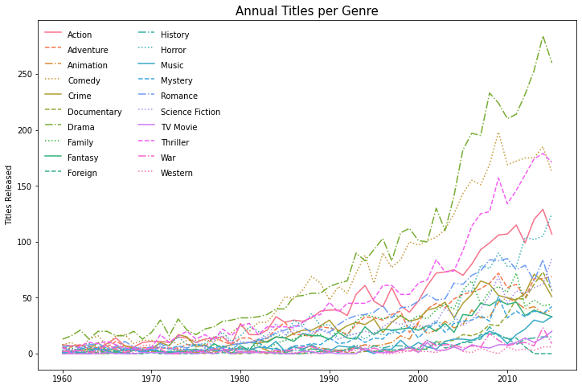

```python
#Get figure and axes for plot
fig, ax = plt.subplots()

# plot formatting
figure_resize(fig, 12, 8)
set_color_palette('husl', len(genre_list), ax)
plt.ylabel("Titles Released")
plt.title('Annual Titles per Genre', fontsize=15)




# While it would be preferable to use built-in functions for this, the fact that each title can
# contain many genres has made it difficult.
# I have tried:
# df.loc[genre_df].groupby('release_year', as_index = True)['revenue_adj'].sum().plot()
# but this appears to force each title into a single category and skews the data.
# This is currently best method I can find for accounting for every instance of a genre for each title.

# Populate plot
for genre in genre_list:
    plot_data = pd.DataFrame(columns=['Year','Titles Released'])
    genre_df = df['genres'].str.contains(genre)

    for year in year_list:
        #number of titles released in this genre on this year
        titles_released = df.loc[genre_df & (df['release_year'] == year)]['original_title'].count()

        #add number of titles to plot data
        new_row = {'Year':year,'Titles Released':titles_released}
        plot_data = plot_data.append(new_row,ignore_index = True)

    plt.plot(plot_data['Year'],
             plot_data['Titles Released'],
             next_line_style(),
             label=genre)

plt.legend(loc='upper left',
           ncol=2,
           handleheight=2.5,
           labelspacing=0.05,
           frameon=False)

plt.show()
```

> At first glance, westerns appear to have consistently ranked among the least titles in every decade sampled.

> Since almost all genres have seen some degree of growth since the 1960s, it will probably be more helpful to look at the number of titles released per genre as a *percent of the total* titles released per year. This should prove give a good indicator of changes in market share over time.

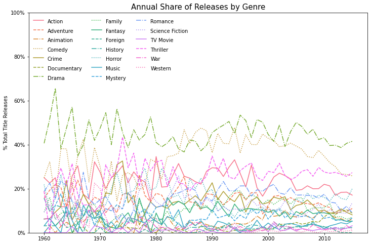

```python
#Get figure and axes for plot
fig, ax = plt.subplots()

#plot formatting
figure_resize(fig, 12, 8)
set_color_palette('husl', len(genre_list), ax)
plt.ylabel("% Total Title Releases")
plt.title('Annual Share of Releases by Genre', fontsize=15)

#Populate plot
for genre in genre_list:
    plot_data = pd.DataFrame(columns=['Year','Titles Released'])
    genre_df = df['genres'].str.contains(genre)
    for year in year_list:

        #number of titles released in this genre on this year
        this_genre = df.loc[genre_df & (df['release_year'] == year)]['original_title'].count()
        this_year = df.loc[(df['release_year'] == year)]['original_title'].count()

        #add percent of total to plot data
        new_row = {'Year':year,'Titles Released': this_genre / this_year}
        plot_data = plot_data.append(new_row,ignore_index = True)

    plt.plot(plot_data['Year'],
             plot_data['Titles Released'],
             next_line_style(),
             label=genre)


#Set axis scale
x1,x2,y1,y2 = plt.axis()
plt.axis((x1,x2,0,1))

#Format y-axis as percent
plot_ticks, axis_ticks = plt.gca().get_yticks(), ax.get_yticks().tolist()
plt.gca().set_yticks(axis_ticks)
plt.gca().set_yticklabels(['{:.0f}%'.format(n*100) for n in plot_ticks])


plt.legend(loc='upper left',
           ncol=3,
           handleheight=2.4,
           labelspacing=0.05,
           frameon=False)

plt.show()
```

> Here we can see a clearer image of the market dominance of drama titles. We can also more clearly see a period in the mid-70s where thrillers almost overtook dramas. These moments of fluctuation appear to be deviances from the norm, however. For the most part, each genre seems to have maintained its relative position in the percent of total releases across the years.

> Examining the number of titles released alone, however, may not be the best metric for determining audience interest. Drama movies may be more commonly produced for a variety of reasons, such as lower production costs. We can only see a correlation here, but we can make no claim as to the cause.

> We will now explore the average budget of films in each genre to see if there is a correlation with the number of releases. If we can eliminate budget as a factor in the number of titles, then we can increase our confidence in the assumption that interest in genres has stayed relatively fixed over time.

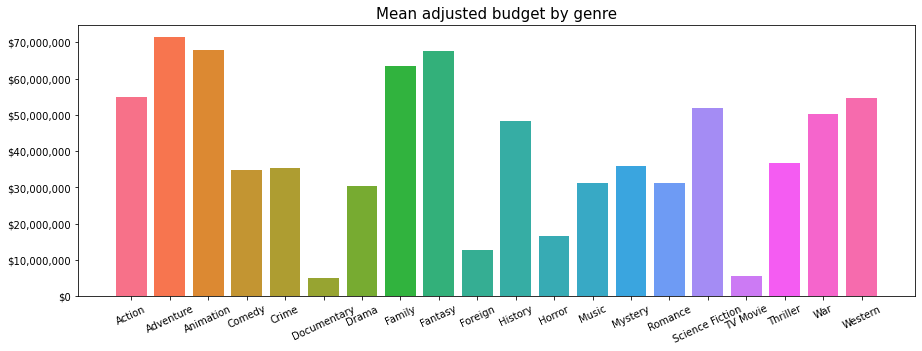

```python
# Comparing mean adjusted budget for each genre

fig, ax = plt.subplots()

#formatting y-axis as dollar figures
ax.yaxis.set_major_formatter('${x:1,.0f}')


#plot formatting
figure_resize(fig, 15, 5)
set_color_palette('husl', len(genre_list), ax)
plt.title('Mean adjusted budget by genre', fontsize=15)
plt.xticks(rotation = 25)

for genre in genre_list:
    plt.bar(genre,df.loc[df['genres'].str.contains(genre)]['budget_adj'].mean())
plt.show()
```

> Here we can see that drama movies have a pretty average budget overall. They're certainly not as cheap to produce as documentaries or TV Movies, but they are far cheaper than Adventure, Animation, and Fantasy. This alone does not appear to be a strong enough indicator to explain why so many drama titles are produced compared to other genres.

> At this point, we can not confidently explain a reason for the consistency each genre has held its place in the market. While this does increase confidence in the possibility of audience tastes remaining relatively fixed over time, we cannot yet confirm this.

> It will, perhaps, be useful to zoom in on drama titles. Let us explore their mean revenue over time.

[figure not shown]

```python
fig, ax = plt.subplots()

#plot formatting
figure_resize(fig, 12, 8)
plt.title('Annual Mean Revenue for Drama Titles', fontsize=15)

#formatting y-axis as dollar figures
ax.yaxis.set_major_formatter('${x:1,.0f}')


df.groupby('release_year', as_index = True)['revenue_adj'].mean().plot()

plt.show()
```

[figure not shown]

```python
fig, ax = plt.subplots()

#plot formatting
figure_resize(fig, 12, 8)
plt.title('Total Annual Revenue for Drama Titles', fontsize=15)

#formatting y-axis as dollar figures
ax.yaxis.set_major_formatter('${x:1,.0f}')

df.groupby('release_year', as_index = True)['revenue_adj'].sum().plot()

plt.show()
```

### What factors are associated with high-profit films?

> What factors influence the profit a film brings in? For instance:

> > How does the choice of genre affect profit?

> > Does the audience liking a title necessarily result in that title making more money? i.e. how strongly correlated are user reviews and revenue?

> For the purposes of this exploration, we will define profit as **revenue_adj - budget_adj**.

### First, let's take a look at some statistics on revenue and budget individually.

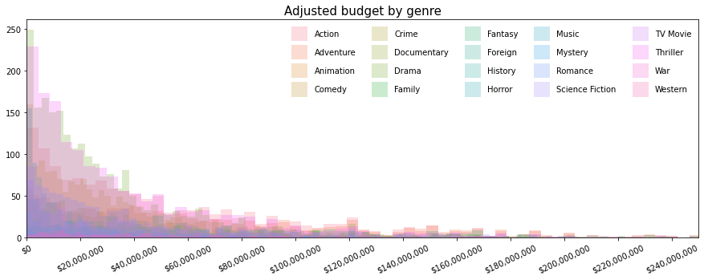

```python
fig, ax = plt.subplots()
ax.xaxis.set_major_formatter('${x:1,.0f}')


#plot formatting
figure_resize(fig, 15, 5)
set_color_palette('husl', len(genre_list), ax)
plt.title('Adjusted budget by genre', fontsize=15)
plt.xticks(rotation = 25)

for genre in genre_list:
    plt.hist(df.loc[df['genres'].str.contains(genre)]['budget_adj'],
             label=genre,
             alpha=0.25,
             bins=100)

plt.legend(loc='upper right',
           ncol=5,
           handleheight=2.4,
           labelspacing=0.5,
           frameon=False)

plt.locator_params(axis='x', nbins=15)

#Set axis scale
x1,x2,y1,y2 = plt.axis()
plt.axis((0,250000000,y1,y2))

plt.show()
```

> Here we can see that the vast majority of titles have under a \$100,000,000 budget.

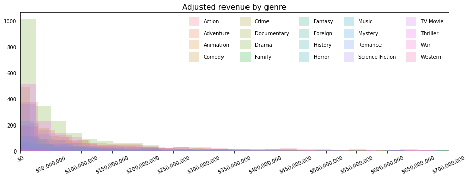

```python
#comparing histogram of budget by genre and revenue
fig, ax = plt.subplots()
ax.xaxis.set_major_formatter('${x:1,.0f}')


#plot formatting
figure_resize(fig, 15, 5)
set_color_palette('husl', len(genre_list), ax)
plt.title('Adjusted revenue by genre', fontsize=15)
plt.xticks(rotation = 25)

for genre in genre_list:
    plt.hist(df.loc[df['genres'].str.contains(genre)]['revenue_adj'],
             label=genre,
             alpha=0.25,
             bins=100)

plt.legend(loc='upper right',
           ncol=5,
           handleheight=2.4,
           labelspacing=0.5,
           frameon=False)

plt.locator_params(axis='x', nbins=15)

#Set axis scale
x1,x2,y1,y2 = plt.axis()
plt.axis((0,700000000,y1,y2))

plt.show()
```

> At the same time, we can see that it is rare for a movie to make greater than \$200,000,000 revenue, and exceedingly rare to gross over \\$500,000,000.

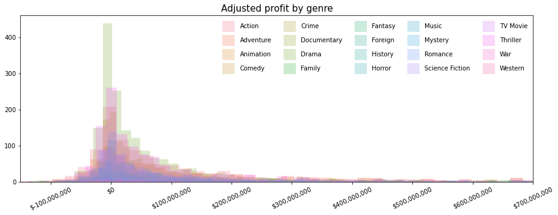

```python
#comparing histogram of budget by genre and revenue
fig, ax = plt.subplots()
ax.xaxis.set_major_formatter('${x:1,.0f}')


#plot formatting
figure_resize(fig, 15, 5)
set_color_palette('husl', len(genre_list), ax)
plt.title('Adjusted profit by genre', fontsize=15)
plt.xticks(rotation = 25)

for genre in genre_list:
    to_plot = df.loc[df['genres'].str.contains(genre)]['revenue_adj'] - df.loc[df['genres'].str.contains(genre)]['budget_adj']
    plt.hist(to_plot,
             label=genre,
             alpha=0.25,
             bins=150)

plt.legend(loc='upper right',
           ncol=5,
           handleheight=2.4,
           labelspacing=0.5,
           frameon=False)

plt.locator_params(axis='x', nbins=15)

#Set axis scale
x1,x2,y1,y2 = plt.axis()
plt.axis((-150000000,700000000,y1,y2))

plt.show()
```

> This is extremely interesting. It would appear that many movies are either bringing in very little profit, or are even losing money. Perhaps the profit made by highly successful movies is enough to offset the risk of a flop.

### Comparing finances by genre

> Now that we've explored some basic financial information in the industry, let's zoom in on some average financial information for each genre.

> Specifically, we will look at mean revenue, mean profit, and mean margin.

> **We will be using the standard formula for calculating gross margin:**

$$m = {100 \cdot \frac{r - c}{r}}$$

> *Where **m** = margin, **c** = costs, and **r** = revenue*

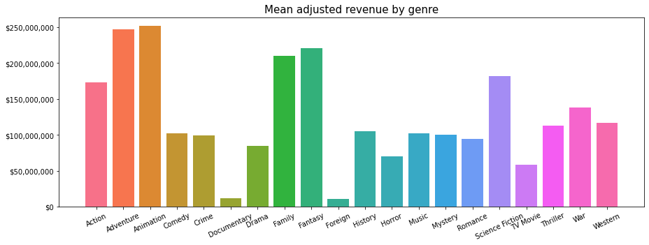

```python
#comparing runtime and revenue
fig, ax = plt.subplots()
ax.yaxis.set_major_formatter('${x:1,.0f}')


#plot formatting
figure_resize(fig, 15, 5)
set_color_palette('husl', len(genre_list), ax)
plt.title('Mean adjusted revenue by genre', fontsize=15)
plt.xticks(rotation = 25)

for genre in genre_list:
    plt.bar(genre,df.loc[df['genres'].str.contains(genre)]['revenue_adj'].mean())
plt.show()
```

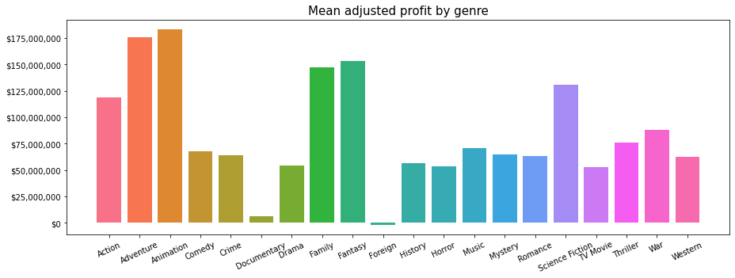

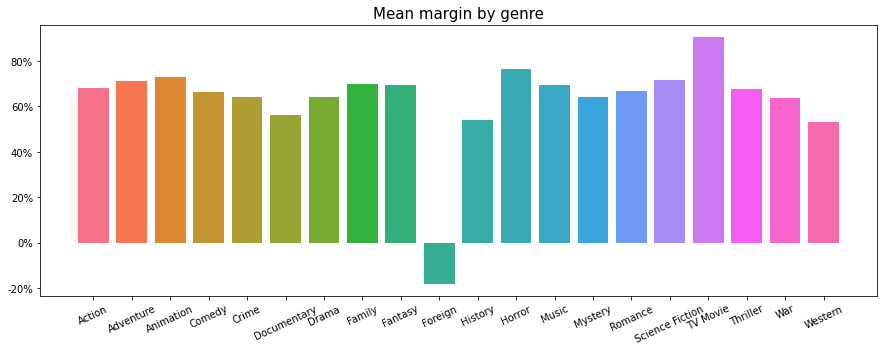

```python
#comparing runtime and revenue
fig, ax = plt.subplots()
ax.yaxis.set_major_formatter('${x:1,.0f}')


#plot formatting
figure_resize(fig, 15, 5)
set_color_palette('husl', len(genre_list), ax)
plt.title('Mean adjusted profit by genre', fontsize=15)
plt.xticks(rotation = 25)

for genre in genre_list:
    revenue = df.loc[df['genres'].str.contains(genre)]['revenue_adj'].mean()
    cost = df.loc[df['genres'].str.contains(genre)]['budget_adj'].mean()
    plt.bar(genre, revenue - cost)
plt.show()


fig, ax = plt.subplots()
ax.yaxis.set_major_formatter('{x:1,.0f}%')


#plot formatting
figure_resize(fig, 15, 5)
set_color_palette('husl', len(genre_list), ax)
plt.title('Mean margin by genre', fontsize=15)
plt.xticks(rotation = 25)

for genre in genre_list:
    revenue = df.loc[df['genres'].str.contains(genre)]['revenue_adj'].mean()
    cost = df.loc[df['genres'].str.contains(genre)]['budget_adj'].mean()
    margin = 100 * ((revenue - cost) / revenue)
    plt.bar(genre, margin)
plt.show()
```

> With unlimited resources, however, adventure and animation are clearly the top two winners in total profit.

> Interestingly, foreign films seem to have a negative margin. It is possible that the data only includes information on revenue generated by United States audiences.

### How are audience votes and revenue correlated?

> How does the opinion of the audience factor into the revenue a movie generates? Are better-liked movies bigger money-makers?

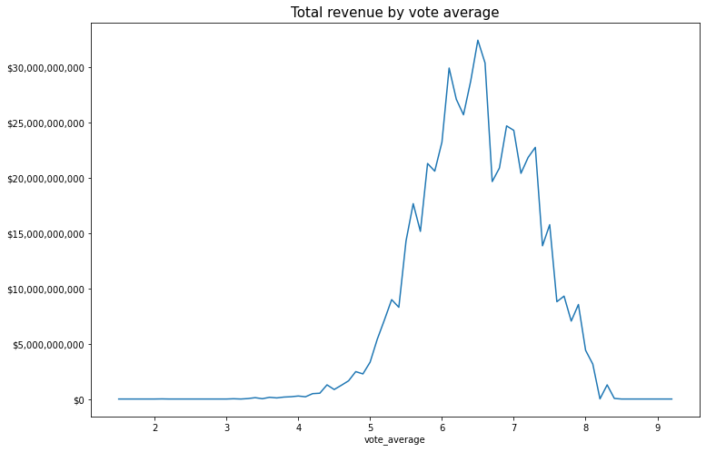

```python
fig, ax = plt.subplots()

#plot formatting
figure_resize(fig, 12, 8)
plt.title('Total revenue by vote average', fontsize=15)

#formatting y-axis as dollar figures
ax.yaxis.set_major_formatter('${x:1,.0f}')

df.groupby('vote_average', as_index = True)['revenue_adj'].sum().plot()

plt.show()
```

> There are many factors that could explain this. It makes sense that generally disliked movies would make less money, but why would movies that are universally loved make less money than those with just average reception?

## Conclusions

> In this report, we have indirectly explored audience preferences in film genre over time, as well as specific factors that may affect a film's profit and revenue.

> **As we did not perform any statistical tests, all findings are tentative and any assumptions may be incorrect.**

> **First, we explored audience preferences over time** and discovered that the total number of films in general, across all genres, has increased since the 1960s. It is possible that this is due to a general increase in demand, but this cannot be definitively stated.

> We then found that, as a percent of total films released in a given year, most genres maintained a relatively stable position in number of titles released for every year from the 1960s to the present date.

> All in all, no specific information was found that would indicate any major change in genre tastes over time.

> **Secondly, we examined factors that may affect a film's profit and revenue.** We started by gathering data about basic financial information. Interestingly, we discovered that many films either lost money, or profited very little.